## Orange County Appraiser Salary Analysis

This notebook explores the trends in salary for employees of Orange County’s Appraiser’s Office from 2011 until 2016. The data was extracted from transparentcalifornia.com.

Two statistics are investigated in this report:

1. How has employee compensation for each role changed over the 5 year period? How has real salary changed relative to benefits.
2. How long does it take for appraiser’s at each level to promote to the next level.

In the future, I’d like to examine the total county budget for each of these years and how the demographics of the county appraiser’s office has changed. How many people who started in 2011 stayed until 2016? Male vs Female split (this would take a while to find because I would need to code the gender of each employee).

#### Question 1: How has compensation changed over time for each position in appraisal?

To answer this question, the total pay and the total benefits will be grouped by job title and year. Then, the data will be plotted independently and finally together to get a larger view of the changes.

#### Analysis of Appraiser I

Appraiser I is the first position to which a trainee is promoted. Here, and in each of the following sections, total pay, total benefits, and promotion statistics will be explored.

##### Total Pay

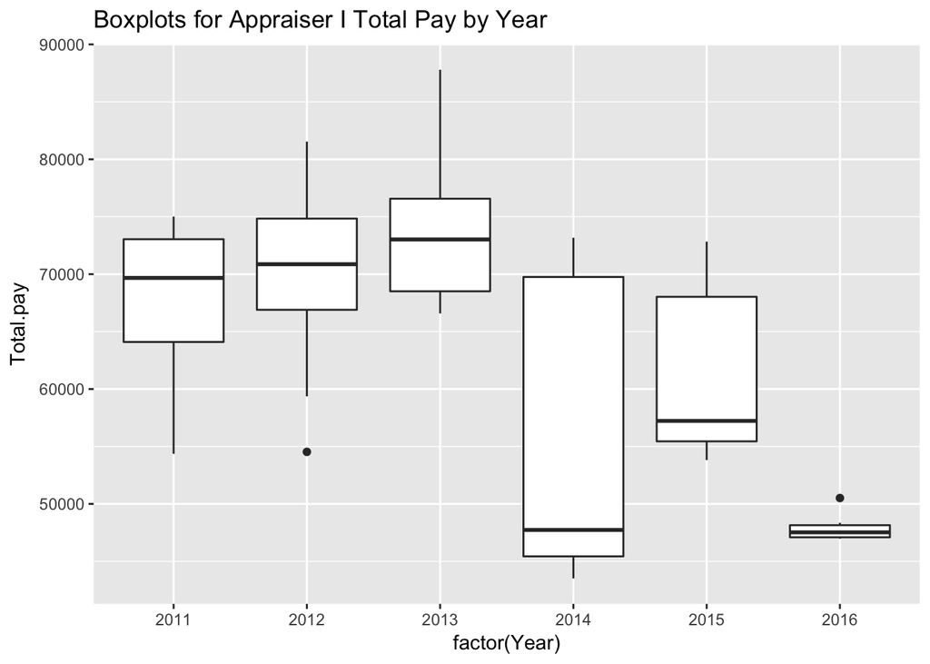

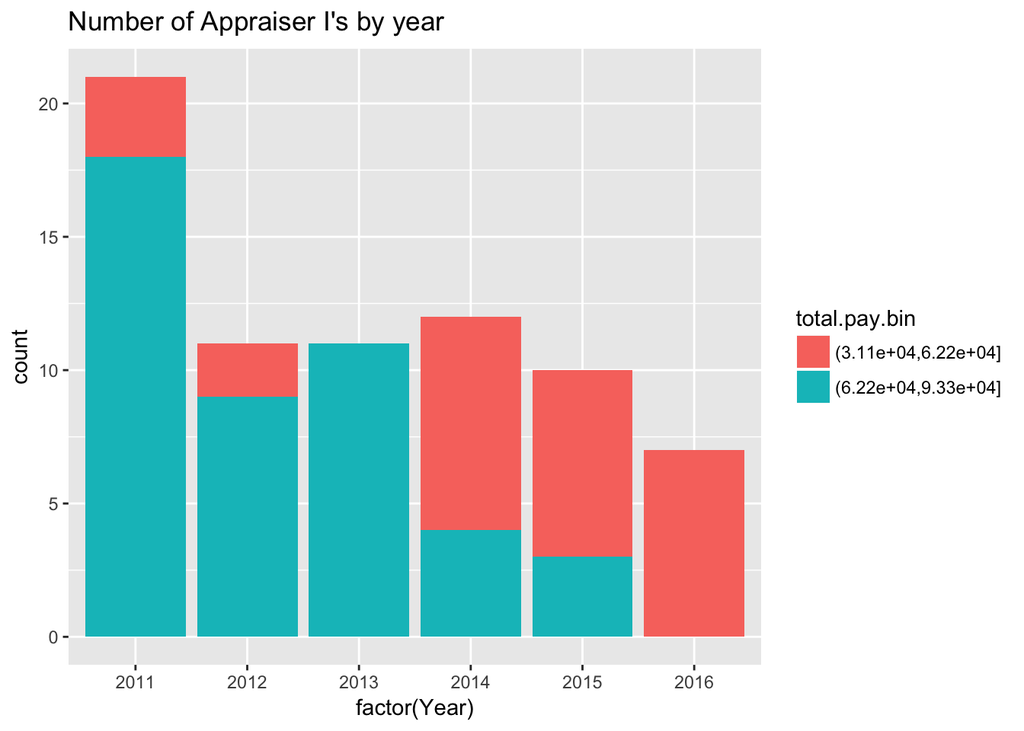

##### Total Benefits

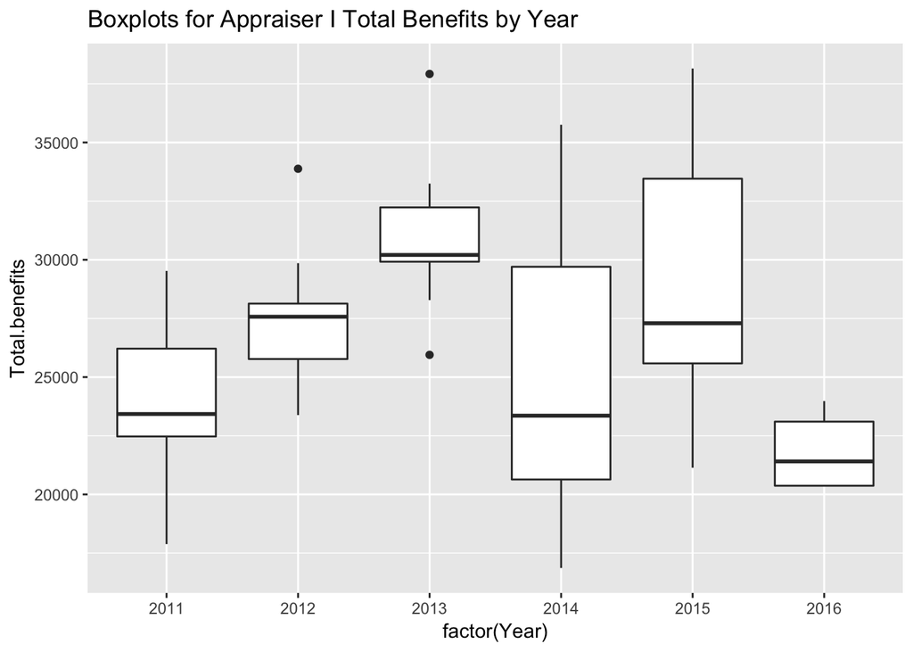

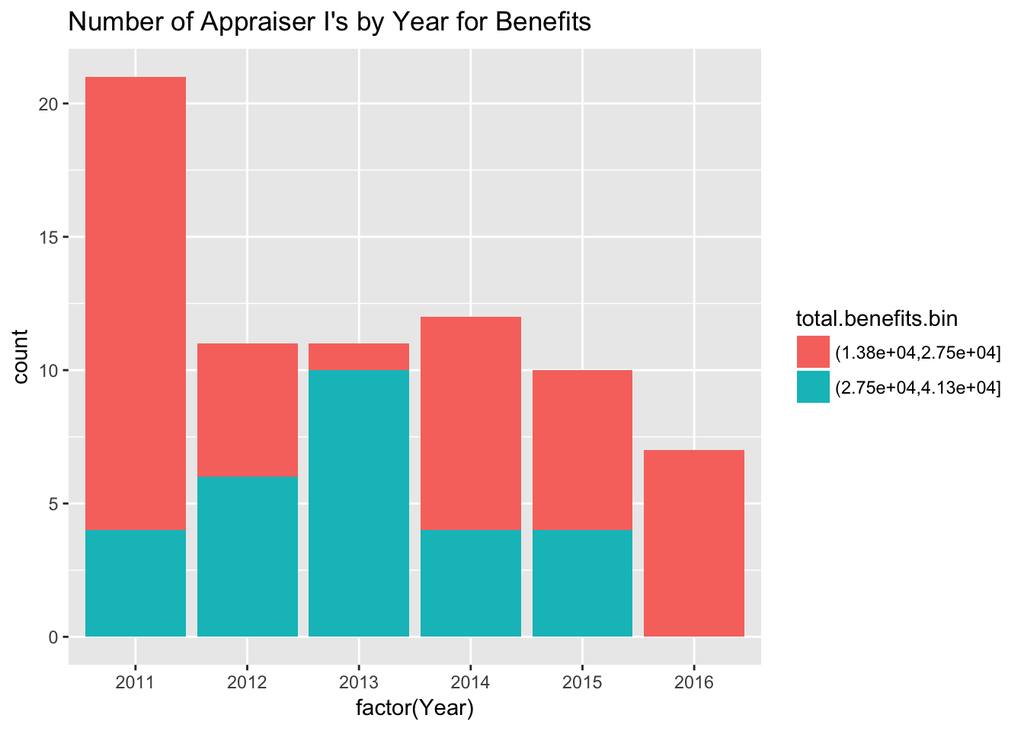

##### Examining Promotion Data For Appraiser Trainee’s to Appraiser I

From the data we can see that there was at one time 25 Appraiser Trainees and 15 were promoted to Appraiser I (60% promotion rate). As the histogram shows below, for those people who were promoted, they took at most one year to become an Appraiser I.

```
## [1] 25
```

```
## [1] 15
```

```
## [1] 0.6
```

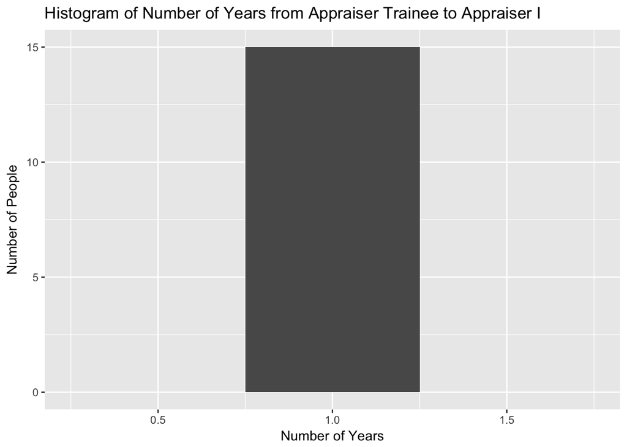

#### Analysis of Appraiser II

##### Total Pay

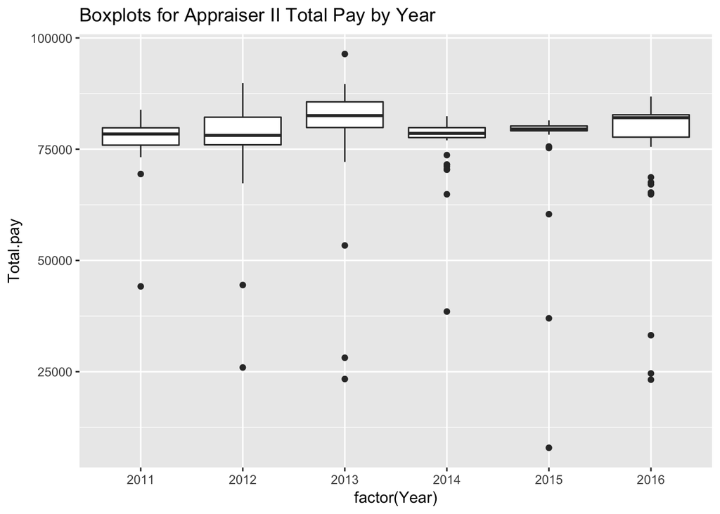

The outliers of this data make the trend in this data less apparent. The next plot shows the boxplots without outliers.

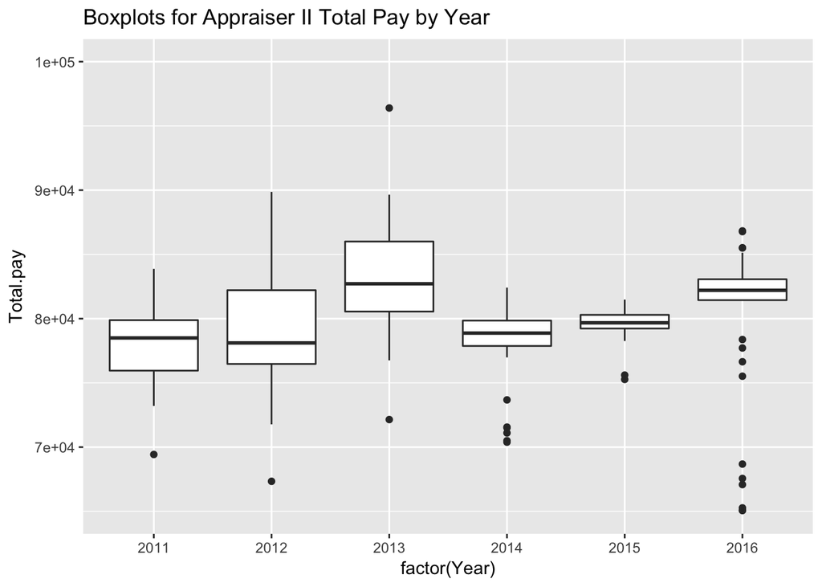

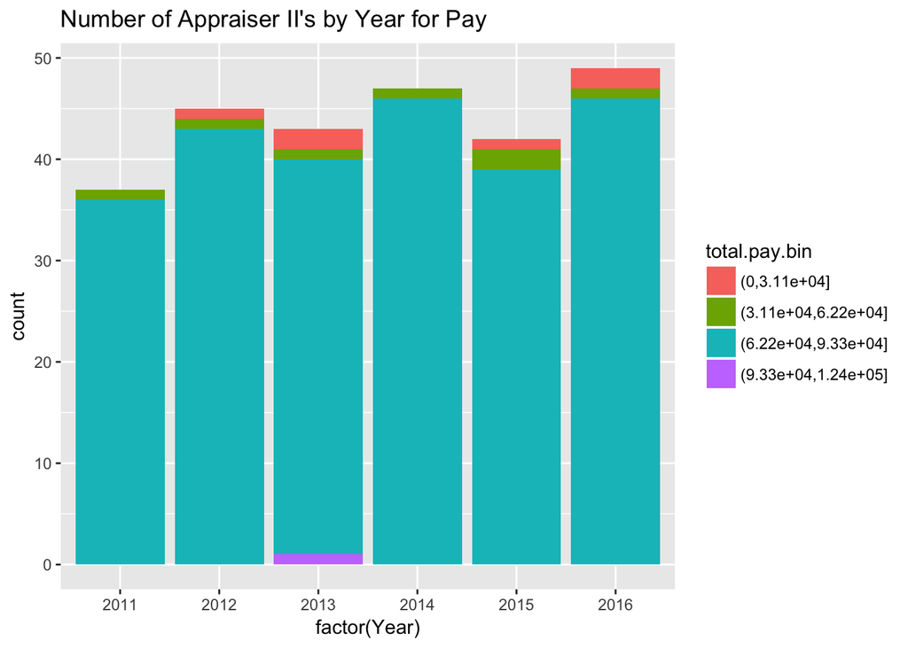

##### Total Benefits

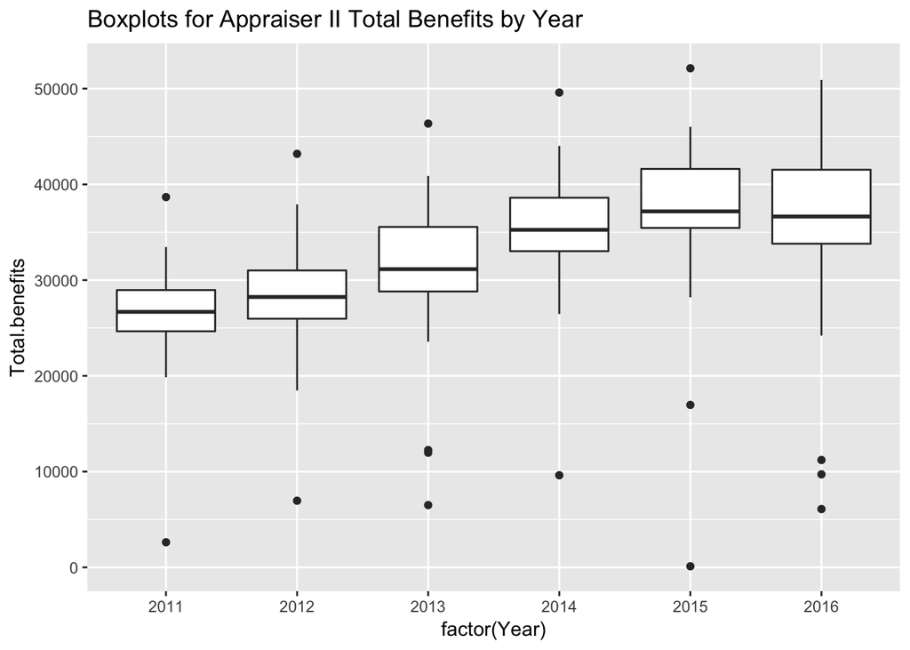

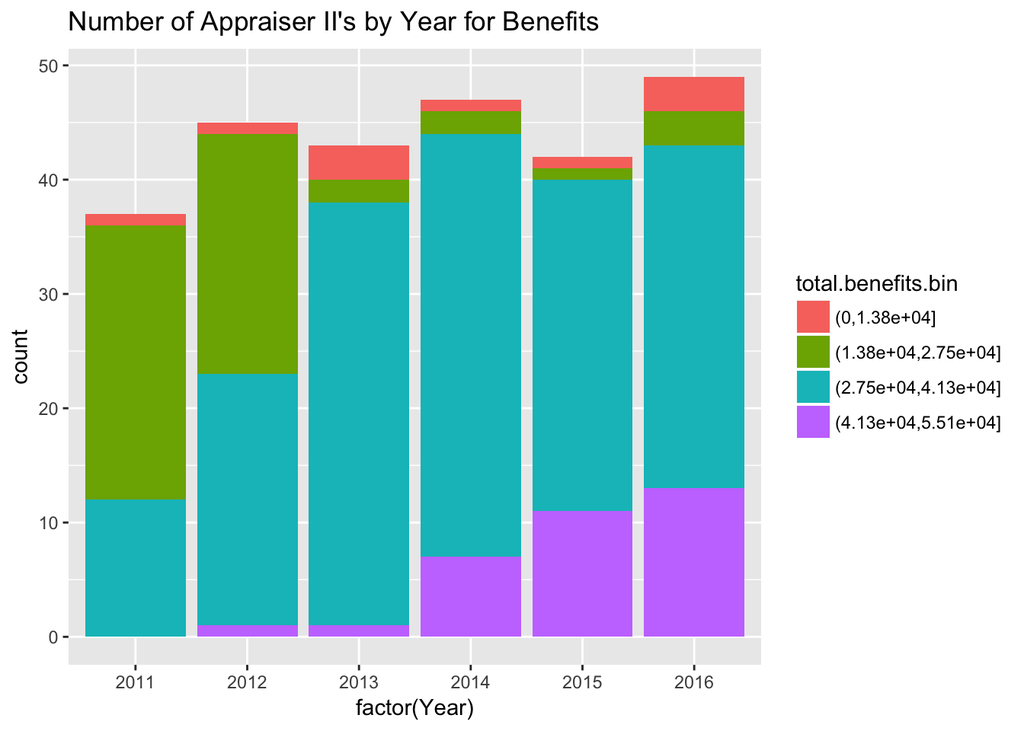

###### Observations from Appraiser II Plots:

The number of employees and their respective salaries are far less variable for Appraiser II’s than Appraiser I’s. Again, the plots show a dip in mean salaries in 2014. The bar chart reveals that the exit one the employee that made close to $100,000 had a significant effect on the change in the mean. Overall, it appears as if Total Pay for Appraiser II’s is increasing.

##### Examining Promotion Data For Appraiser I to Appraiser II

```
## [1] 72
```

```
## [1] 60
```

```
## [1] 0.8333333
```

```
##    Min. 1st Qu.  Median    Mean 3rd Qu.    Max.
##   1.000   2.000   3.000   2.933   3.500   5.000
```

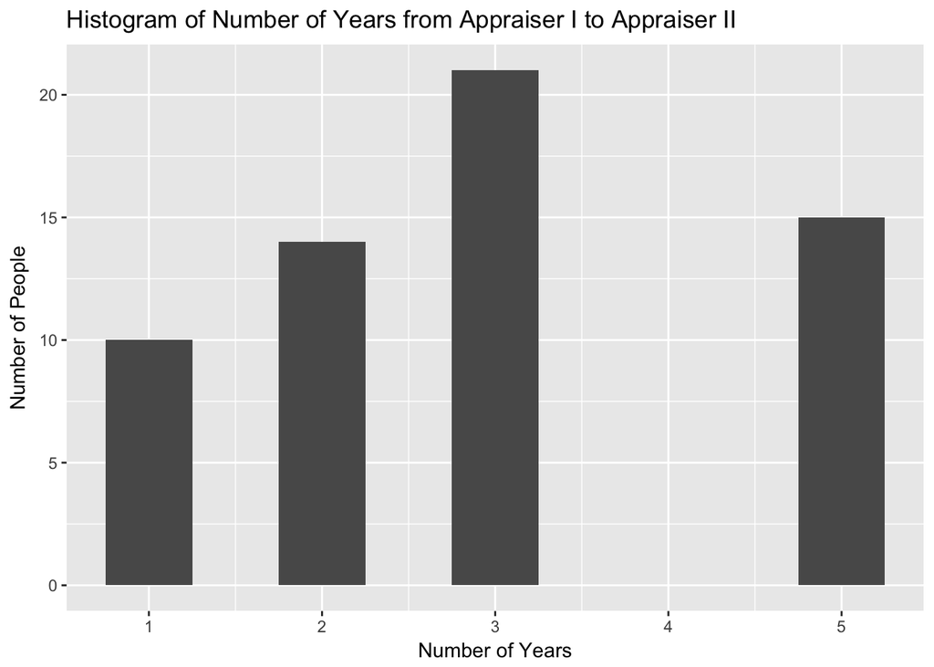

#### Analysis of Appraiser III

##### Total Pay

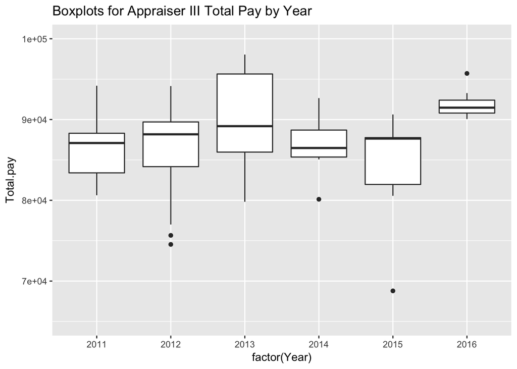

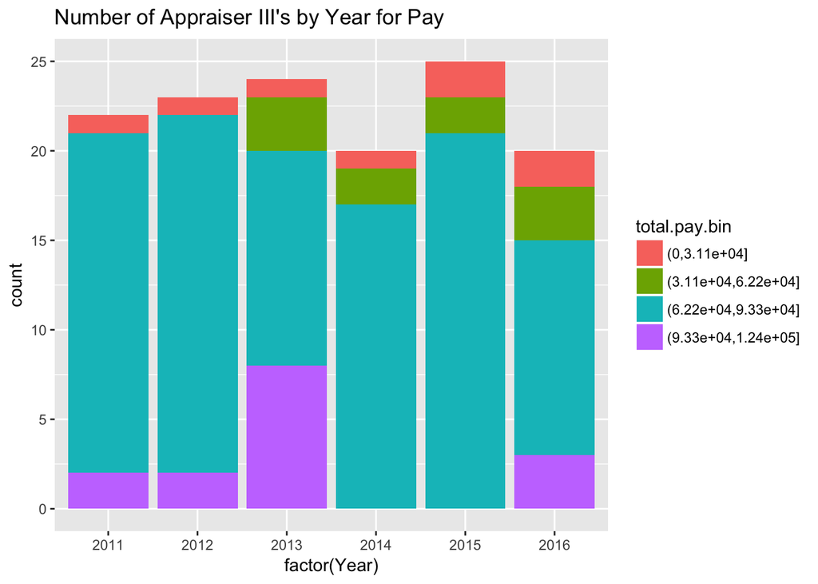

##### Total Benefits

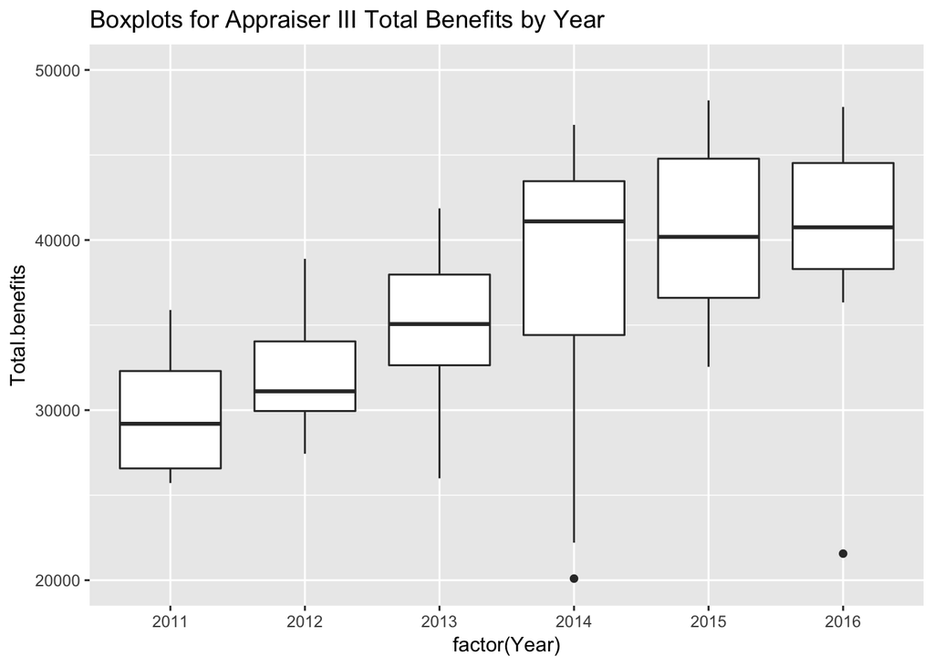

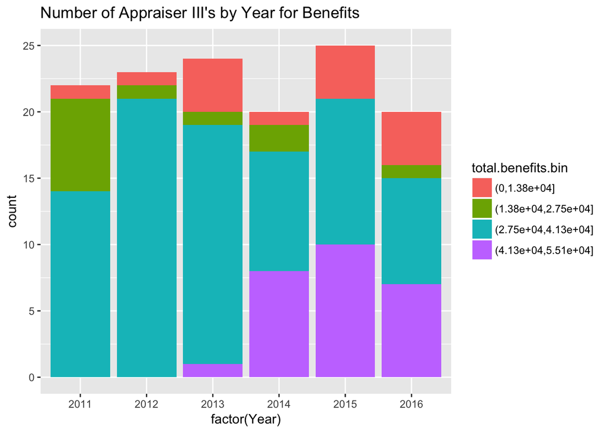

##### Examining Promotion Data For Appraiser II to Appraiser III

From the data we can see that there was at one time 263 Appraiser II and 31 were promoted to Appraiser II (11.78% promotion rate). The median number of years to promotion was 4 and the mean was 3.29.

```
## [1] 263
```

```
## [1] 31
```

```
## [1] 0.1178707
```

```
##    Min. 1st Qu.  Median    Mean 3rd Qu.    Max.
##   1.000   3.000   4.000   3.296   4.000   4.000
```

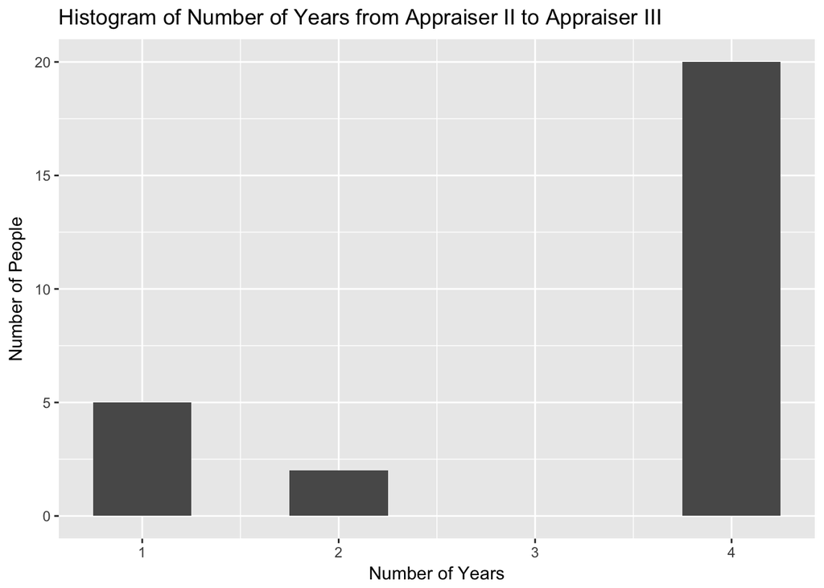